# lab 13

Author

Olivia Kelly

```r
getwd()
```

```
[1] "/home/oakelly_umass_edu/GenomelabS3"
```

```r
list.files("..")              # what’s one level up?
```

```
 [1] "addition_test"                 "confirmed_cases.gif"
 [3] "cumulative_deaths.gif"         "daily_counts_US.gif"
 [5] "data"                          "Exported Items 2.bib"
 [7] "Exported Items 3.bib"          "Exported Items.bib"
 [9] "Exported Items.bib 1"          "GenomelabS3"
[11] "Human Genome class zotero.bib" "images.jpeg"
[13] "Lab 1s.html"                   "Lab 2s.html"
[15] "Lab 2s.qmd"                    "Lab 3.html"
[17] "Lab 3.qmd"                     "Lab 4.html"
[19] "Lab 4.qmd"                     "Lab 5.html"
[21] "Lab 5.qmd"                     "Lab 6.html"
[23] "Lab 6.qmd"                     "Lab 7.html"
[25] "Lab 7.qmd"                     "Lab1.html"
[27] "Lab1.qmd"                      "Lab1s.html"
[29] "Lab1s.qmd"                     "Lab2.html"
[31] "Lab2.qmd"                      "LABS3Genome-"
[33] "mpg-plot.png"                  "My Library 2.bib"
[35] "My Library.bib"                "myhistory.txt"
[37] "myhistoryS5.txt"               "ondemand"
[39] "pathogen"                      "R"
[41] "sbatch_addition.sh"            "slurm-48960422.out"
[43] "slurm-48960431.out"            "slurm-48960439.out"
[45] "slurm-48960485.out"            "slurm-48960489.out"
[47] "slurm-48960491.out"            "slurm-48960500.out"
[49] "test_folder"                   "untitled.txt"
```

```r
list.files("../data")         # does 'data' exist?
```

```
[1] "time_series_covid19_confirmed_global.csv"
[2] "time_series_covid19_deaths_global.csv"
```

```r
list.files("../data/NEON_metadata")  # does this folder exist?
```

```
character(0)
```

```r
list.files("../data", recursive = TRUE)
```

```
[1] "time_series_covid19_confirmed_global.csv"
[2] "time_series_covid19_deaths_global.csv"
```

```r
library(tidyverse)
library(knitr)
library(janitor)
library(DT)
```

```r
iris_setosa <- iris |>
filter(Species == "setosa") |>
filter(Sepal.Length > 5)
```

```r
library(knitr)
kable(iris_setosa)
```

| Sepal.Length | Sepal.Width | Petal.Length | Petal.Width | Species |
| --- | --- | --- | --- | --- |
| 5.1 | 3.5 | 1.4 | 0.2 | setosa |
| 5.4 | 3.9 | 1.7 | 0.4 | setosa |
| 5.4 | 3.7 | 1.5 | 0.2 | setosa |
| 5.8 | 4.0 | 1.2 | 0.2 | setosa |
| 5.7 | 4.4 | 1.5 | 0.4 | setosa |
| 5.4 | 3.9 | 1.3 | 0.4 | setosa |
| 5.1 | 3.5 | 1.4 | 0.3 | setosa |
| 5.7 | 3.8 | 1.7 | 0.3 | setosa |
| 5.1 | 3.8 | 1.5 | 0.3 | setosa |
| 5.4 | 3.4 | 1.7 | 0.2 | setosa |
| 5.1 | 3.7 | 1.5 | 0.4 | setosa |
| 5.1 | 3.3 | 1.7 | 0.5 | setosa |
| 5.2 | 3.5 | 1.5 | 0.2 | setosa |
| 5.2 | 3.4 | 1.4 | 0.2 | setosa |
| 5.4 | 3.4 | 1.5 | 0.4 | setosa |
| 5.2 | 4.1 | 1.5 | 0.1 | setosa |
| 5.5 | 4.2 | 1.4 | 0.2 | setosa |
| 5.5 | 3.5 | 1.3 | 0.2 | setosa |
| 5.1 | 3.4 | 1.5 | 0.2 | setosa |
| 5.1 | 3.8 | 1.9 | 0.4 | setosa |
| 5.1 | 3.8 | 1.6 | 0.2 | setosa |
| 5.3 | 3.7 | 1.5 | 0.2 | setosa |

```r
library(DT)
datatable(iris_setosa)
```

|  | Sepal.Length | Sepal.Width | Petal.Length | Petal.Width | Species |
| --- | --- | --- | --- | --- | --- |
| 1 | 5.1 | 3.5 | 1.4 | 0.2 | setosa |
| 2 | 5.4 | 3.9 | 1.7 | 0.4 | setosa |
| 3 | 5.4 | 3.7 | 1.5 | 0.2 | setosa |
| 4 | 5.8 | 4 | 1.2 | 0.2 | setosa |
| 5 | 5.7 | 4.4 | 1.5 | 0.4 | setosa |
| 6 | 5.4 | 3.9 | 1.3 | 0.4 | setosa |
| 7 | 5.1 | 3.5 | 1.4 | 0.3 | setosa |
| 8 | 5.7 | 3.8 | 1.7 | 0.3 | setosa |
| 9 | 5.1 | 3.8 | 1.5 | 0.3 | setosa |
| 10 | 5.4 | 3.4 | 1.7 | 0.2 | setosa |

[output cut: 12 more lines]

```r
datatable(
  iris |>
    filter(Species == "setosa") |>
    filter(Sepal.Length > 5)
)
```

|  | Sepal.Length | Sepal.Width | Petal.Length | Petal.Width | Species |
| --- | --- | --- | --- | --- | --- |
| 1 | 5.1 | 3.5 | 1.4 | 0.2 | setosa |
| 2 | 5.4 | 3.9 | 1.7 | 0.4 | setosa |
| 3 | 5.4 | 3.7 | 1.5 | 0.2 | setosa |
| 4 | 5.8 | 4 | 1.2 | 0.2 | setosa |
| 5 | 5.7 | 4.4 | 1.5 | 0.4 | setosa |
| 6 | 5.4 | 3.9 | 1.3 | 0.4 | setosa |
| 7 | 5.1 | 3.5 | 1.4 | 0.3 | setosa |
| 8 | 5.7 | 3.8 | 1.7 | 0.3 | setosa |
| 9 | 5.1 | 3.8 | 1.5 | 0.3 | setosa |
| 10 | 5.4 | 3.4 | 1.7 | 0.2 | setosa |

[output cut: 12 more lines]

```r
iris_setosa <- iris |>
  filter(Species == "setosa") |>
  filter(Sepal.Length > 5)

datatable(iris_setosa)
```

|  | Sepal.Length | Sepal.Width | Petal.Length | Petal.Width | Species |
| --- | --- | --- | --- | --- | --- |
| 1 | 5.1 | 3.5 | 1.4 | 0.2 | setosa |
| 2 | 5.4 | 3.9 | 1.7 | 0.4 | setosa |
| 3 | 5.4 | 3.7 | 1.5 | 0.2 | setosa |
| 4 | 5.8 | 4 | 1.2 | 0.2 | setosa |
| 5 | 5.7 | 4.4 | 1.5 | 0.4 | setosa |
| 6 | 5.4 | 3.9 | 1.3 | 0.4 | setosa |
| 7 | 5.1 | 3.5 | 1.4 | 0.3 | setosa |
| 8 | 5.7 | 3.8 | 1.7 | 0.3 | setosa |
| 9 | 5.1 | 3.8 | 1.5 | 0.3 | setosa |
| 10 | 5.4 | 3.4 | 1.7 | 0.2 | setosa |

[output cut: 12 more lines]

```r
NEON_MAGs <- read_tsv("/work/pi_bio678_umass_edu/data_NEON/exported_img_bins_Gs0166454_NEON.tsv")
```

  ```r
  colnames(NEON_MAGs)
  ```

  ```
   [1] "bin_oid"               "Bin ID"                "Genome Name"
   [4] "IMG Genome ID"         "Bin Quality"           "Bin Lineage"
   [7] "GTDB Taxonomy Lineage" "Bin Methods"           "Created By"
  [10] "Date Added"            "Bin Completeness"      "Bin Contamination"
  [13] "Average Coverage"      "Total Number of Bases" "5s rRNA"
  [16] "16s rRNA"              "23s rRNA"              "tRNA Genes"
  [19] "Gene Count"            "Scaffold Count"        "GOLD Study ID"
  ```

```r
library(tidyverse)
library(DT)
library(vegan)
library(igraph)
```

### 1. Taxonomic profiling-

```r
library(tidyverse)

NEON_MAGs %>%
  count(`GTDB Taxonomy Lineage`) %>%
  arrange(desc(n))
```

```
# A tibble: 2,380 × 2
   `GTDB Taxonomy Lineage`                                                     n
   <chr>                                                                   <int>
 1 Bacteria; Acidobacteriota; Terriglobia; Acidoferrales; UBA7541; Acidof…   307
 2 Bacteria; Actinomycetota; Thermoleophilia; Solirubrobacterales; Soliru…   239
 3 Bacteria; Pseudomonadota; Alphaproteobacteria; Rhizobiales; Xanthobact…   207
 4 Bacteria; Actinomycetota; Actinomycetes; Mycobacteriales; Mycobacteria…   203
 5 Bacteria; Actinomycetota; Thermoleophilia; Solirubrobacterales; Soliru…   197
 6 Bacteria; Pseudomonadota; Alphaproteobacteria; Rhizobiales; Xanthobact…   196
 7 Bacteria; Pseudomonadota; Gammaproteobacteria; Steroidobacterales; Ste…   190
 8 Bacteria; Pseudomonadota; Alphaproteobacteria; Rhizobiales; Xanthobact…   186
 9 Bacteria; Acidobacteriota; Terriglobia; Acidoferrales; UBA7541; Palsa-…   173
10 Bacteria; Pseudomonadota; Gammaproteobacteria; Steroidobacterales; Ste…   155
# ℹ 2,370 more rows
```

[figure not shown]

```r
library(dplyr)
library(ggplot2)

taxa_summary <- NEON_MAGs %>%
  count(`Bin Lineage`, `GTDB Taxonomy Lineage`) %>%
  group_by(`Bin Lineage`) %>%
  mutate(rel_abundance = n / sum(n))

ggplot(taxa_summary, aes(x = `Bin Lineage`, y = rel_abundance, fill = `GTDB Taxonomy Lineage`)) +
  geom_bar(stat = "identity") +
  labs(title = "Relative Abundance of Taxa by Site",
       y = "Relative Abundance", x = "Site")
```

```r
library(dplyr)
library(stringr)

# Assume your taxonomy column is called "GTDB Taxonomy Lineage"
NEON_MAGs_clean <- NEON_MAGs %>%
  mutate(
    phylum = str_split(`GTDB Taxonomy Lineage`, ";") %>%
             sapply(function(x) ifelse(length(x) >= 2, str_trim(x[2]), NA)),
    class  = str_split(`GTDB Taxonomy Lineage`, ";") %>%
             sapply(function(x) ifelse(length(x) >= 3, str_trim(x[3]), NA))
  )
```

[figure not shown]

```r
NEON_MAGs_clean %>%
  count(`Bin Lineage`, phylum) %>%
  group_by(`Bin Lineage`) %>%
  mutate(rel_abundance = n / sum(n)) %>%
  ggplot(aes(x = `Bin Lineage`, y = rel_abundance, fill = phylum)) +
  geom_bar(stat = "identity") +
  labs(title = "Relative Abundance of Phyla by Site",
       y = "Relative Abundance", x = "Site")
```

```r
unique(NEON_MAGs$`Bin Lineage`)
```

```
  [1] "Bacteria"
  [2] NA
  [3] "Bacteria; Actinomycetota; Thermoleophilia; Solirubrobacterales"
  [4] "Bacteria; Acidobacteriota; Terriglobia"
  [5] "Bacteria; Acidobacteriota; Terriglobia; Terriglobales"
  [6] "Bacteria; Pseudomonadota; Alphaproteobacteria; Hyphomicrobiales; Beijerinckiaceae; Methylocapsa; Methylocapsa sp. S129"
  [7] "Archaea; Euryarchaeota; Methanomicrobia; Methanomicrobiales; Methanoregulaceae; Methanoregula; Methanoregula boonei"
  [8] "Bacteria; Actinomycetota"
  [9] "Bacteria; Pseudomonadota; Alphaproteobacteria; Hyphomicrobiales; Hyphomicrobiaceae; Methyloceanibacter"
 [10] "Bacteria; Thermodesulfobacteriota; Syntrophia; Syntrophales"
 [11] "Bacteria; Acidobacteriota"
 [12] "Bacteria; Thermodesulfobacteriota"
 [13] "Bacteria; Pseudomonadota; Alphaproteobacteria; Hyphomicrobiales"
 [14] "Bacteria; Pseudomonadota; Alphaproteobacteria; Hyphomicrobiales; Nitrobacteraceae; Bradyrhizobium"
 [15] "Bacteria; Pseudomonadota; Alphaproteobacteria; Rhodospirillales"
```

[output cut: 724 more lines]

### 2. Alpha Diversity

[output not shown]

```r
library(dplyr)
library(tidyr)
library(vegan)

# Build site × taxonomy table, dropping rows with missing site info
site_taxa <- NEON_MAGs %>%
  filter(!is.na(`Bin Lineage`), `Bin Lineage` != "") %>%
  count(`Bin Lineage`, `GTDB Taxonomy Lineage`) %>%
  pivot_wider(names_from = `GTDB Taxonomy Lineage`,
              values_from = n,
              values_fill = 0)

# Convert to numeric matrix
mat <- as.matrix(site_taxa[,-1])
mode(mat) <- "numeric"
rownames(mat) <- make.unique(site_taxa$`Bin Lineage`)

# Compute alpha diversity: richness only
diversity_metrics <- data.frame(
  site     = rownames(mat),
  richness = specnumber(mat)   # number of distinct taxa per site
)

# View results
diversity_metrics
```

[output not shown]

[output cut: 1461 more lines]

### 3. Beta diversity: Compare community composition between sites using Bray-Curtis or UniFrac distances.

Perfect — now we’re moving from **alpha diversity (within-site)** to **beta diversity (between-site)**. Beta diversity compares how similar or different communities are across sites.

### 🌱 UniFrac Distance

- **Definition:** A phylogenetic measure of beta diversity that compares communities based on the fraction of branch length unique to each community in a phylogenetic tree.
- **Types:**
  - **Unweighted UniFrac:** Considers only presence/absence.
  - **Weighted UniFrac:** Incorporates relative abundances.
- **Range:** 0 (identical phylogenetic composition) → 1 (completely distinct).
- **Use case:** Requires a phylogenetic tree of your MAGs or OTUs.

```r
library(vegan)

# mat = site × taxa abundance matrix (already built earlier)
# Compute Bray-Curtis dissimilarity
bray_dist <- vegdist(mat, method = "bray")

# Perform NMDS ordination
nmds <- metaMDS(mat, distance = "bray", k = 2)
```

```
Square root transformation
Wisconsin double standardization
*** Best solution was not repeated -- monoMDS stopping criteria:
    20: scale factor of the gradient < sfgrmin
```

[figure not shown]

```r
# Plot NMDS
plot(nmds, type = "t", main = "NMDS of Bray-Curtis Dissimilarity")
```

### 4. Ordination: Perform PCA, NMDS, or PCoA to visualize differences in microbial communities.

PCA works best on normalized abundance data

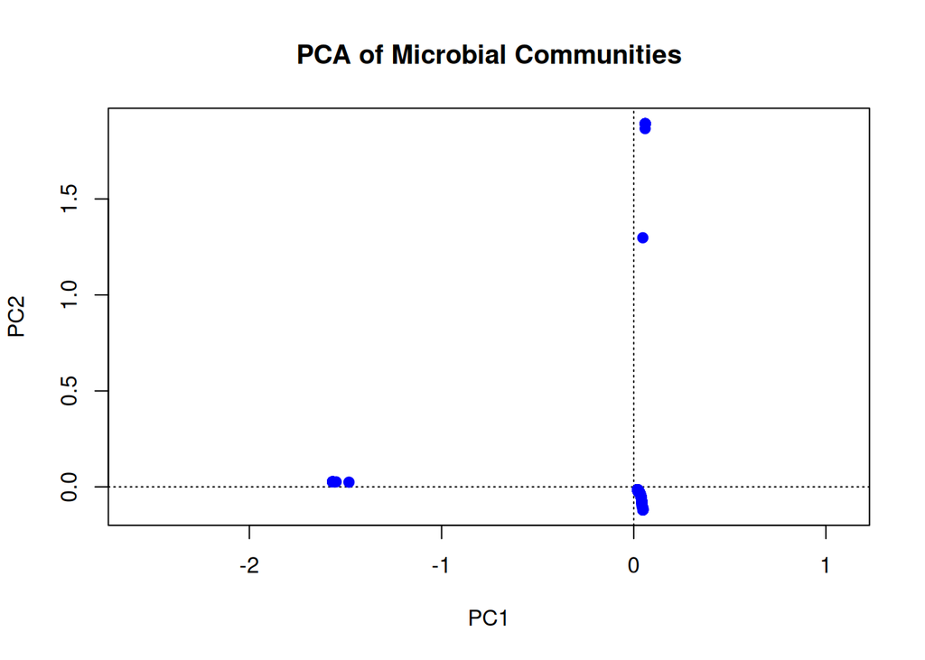

```r
library(vegan)

# Normalize abundances (Hellinger transform is common for community data)
mat_hell <- decostand(mat, method = "hellinger")

# PCA
pca_res <- rda(mat_hell)

# Plot PCA
plot(pca_res, type = "n", main = "PCA of Microbial Communities")
points(pca_res, display = "sites", col = "blue", pch = 19)
```

MDS is robust for ecological data and uses dissimilarity (e.g., Bray–Curtis).

```r
library(vegan)
library(ggplot2)

# Run NMDS on your site × taxa matrix
nmds_res <- metaMDS(mat, distance = "bray", k = 2, trymax = 50)
```

```
Square root transformation
Wisconsin double standardization
*** Best solution was not repeated -- monoMDS stopping criteria:
    50: scale factor of the gradient < sfgrmin
```

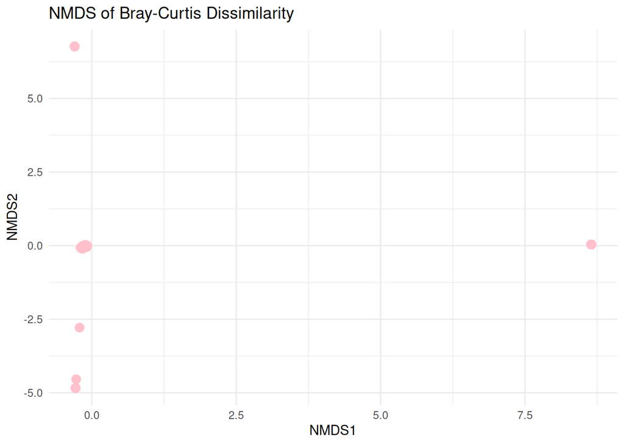

```r
# Extract site scores (coordinates for each site in ordination space)
site_scores <- as.data.frame(scores(nmds_res, display = "sites"))
site_scores$site <- rownames(site_scores)

# Plot NMDS
ggplot(site_scores, aes(x = NMDS1, y = NMDS2)) +
  geom_point(size = 3, color = "pink") +
  theme_minimal() +
  labs(title = "NMDS of Bray-Curtis Dissimilarity",
       x = "NMDS1", y = "NMDS2")
```

PCoA is similar to PCA but works directly on a distance matrix.

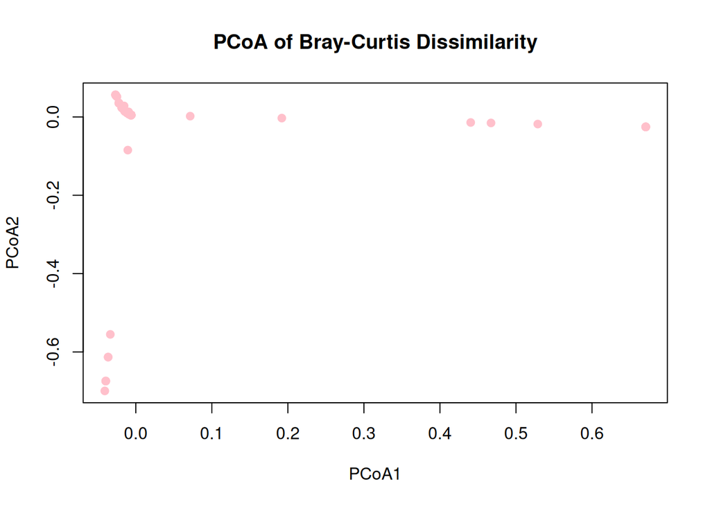

```r
# Bray-Curtis distance
bray_dist <- vegdist(mat, method = "bray")

# PCoA
pcoa_res <- cmdscale(bray_dist, k = 2, eig = TRUE)

# Plot PCoA
plot(pcoa_res$points[,1], pcoa_res$points[,2],
     xlab = "PCoA1", ylab = "PCoA2",
     main = "PCoA of Bray-Curtis Dissimilarity",
     pch = 19, col = "pink")
```